# Como criar um blog com Distill

Passos para criar um blog no github com distill.

Euler Alencar  
2021-12-24

# Distill

Distill é um pacote desenvolvido para R Markdown. Basicamente é um ecossistema de pacotes para a criação de documentos computacionais em R. O objetivo do pacote Distill é fornecer um formato de saída otimizado para comunicação científica e técnica online. O pacote Distill R fornece dois formatos de saída HTML para documentos R Markdown:

- Artigos HTML únicos (distill_article) e
- Sites HTML de várias páginas, incluindo blogs (distill_website).

Esses formatos são baseados na `Distill web framework` usada pelo Distill Machine Learning Journal ([Olah et al. 2018](https://distill.pub/journal/)). A estrutura da web do Distill foi originalmente desenvolvida para nortear uma comunicação técnica e científica mais envolvente e eficaz.

[figure not shown]

Isso não foi nada científico!!!

## Configuração inicial

```r
# Comando inicial ---------------------------------------------------------

# passo 1: Instalação dos pacotes essenciaos
install.packages(c("usethis", "distill"))

# passo 2: Criar um novo projeto
usethis::create_project("portfolioEuler")
```

Compare as duas telas do RStudio, a do novo projeto criado e onde você digitou os comandos acima. Pode fechar a primeira janela do R-Studio e ficar somente com a tela do Projeto aberta.

## Configuração do github para criar o blog

```r
# Configuranção do Github -------------------------------------------------

#passo 3:
usethis::use_git_config(user.name = "euleralencar",
                        user.email = "euleralencar@gmail.com")

# passo 3.5: Criar o Token no github
usethis::create_github_token()

# passo 3.75: Setar o token no R
gitcreds::gitcreds_set()

# passo 4: Usar o git
usethis::use_git()

# sair do projeto e voltar

# passo 5: Criar o projeto no github
usethis::use_github()

# passo 6: Vai criar a página no Github Pages
usethis::use_github_pages("master", "/docs")
```

Veja no seu github se aparece a mesma tela:

[figure not shown]

Crie o arquivo `.nojekyll` e depois use o distill para configurar o ambiente do blog.

```r
#passo 7:
file.create(".nojekyll")
#list.files(all.files = TRUE)

#passo 8:
distill::create_blog(".", "Portfolio Euler", gh_pages = TRUE)

#passo 9:
distill::create_post("Título do Meu Primeiro Post")

#passo 10: commit e push
# -> Pode comitar diretamente do RStudio

#passo 11: acessar [seu_login].github.io/[seu_repositorio]
```

```r
# Criando novo post -------------------------------------------------------

distill::create_post("Como criar um blog no Distill")
```

Ao criar um novo post será criado um rmarkdown deste modelo:

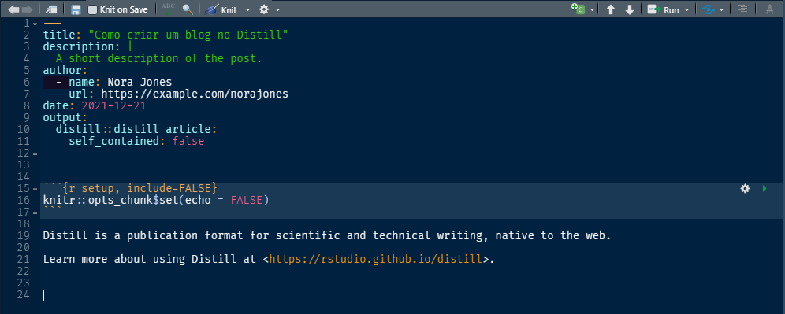

Após finalizar o processo, dê o commit e suba para o github.

### Observação

Sempre que for customizar o blog, tome o cuidado de primeiramente gitar o projeto. Caso dê algum erro, apenas volte para versão anterior. De preferência, crie uma nova branch e depois junte ao master do seu git.

## Referências

- https://themockup.blog/posts/2020-08-01-building-a-blog-with-distill/
- https://rstudio.github.io/distill/blog.html
- https://www.rstudio.com/blog/distill/#ref-olah2018the

Distill is a publication format for scientific and technical writing, native to the web.

Learn more about using Distill at https://rstudio.github.io/distill.